# Proyecto EasyVisa

### Ajuste de hiperparámetros - XGBoost Classifier

```python
# Choose the type of classifier.
xgb_tuned = XGBClassifier(random_state=1, eval_metric="logloss")

# Grid of parameters to choose from
parameters = {
    "n_estimators": np.arange(150, 250, 50),
    "scale_pos_weight": [1, 2],
    "subsample": [0.9, 1],
    "learning_rate": np.arange(0.1, 0.21, 0.1),
    "gamma": [3, 5],
    "colsample_bytree": [0.8, 0.9],
    "colsample_bylevel": [ 0.9, 1],
}

# Type of scoring used to compare parameter combinations
acc_scorer = metrics.make_scorer(metrics.f1_score)

# Run the grid search
grid_obj = GridSearchCV(xgb_tuned, parameters, scoring=acc_scorer,cv=5)
grid_obj = grid_obj.fit(X_train, y_train)



xgb_tuned = grid_obj.best_estimator_

# Fit the best algorithm to the data.
xgb_tuned.fit(X_train, y_train)
```

```
XGBClassifier(base_score=None, booster=None, callbacks=None,
              colsample_bylevel=1, colsample_bynode=None, colsample_bytree=0.8,
              device=None, early_stopping_rounds=None, enable_categorical=False,
              eval_metric='logloss', feature_types=None, gamma=5,
              grow_policy=None, importance_type=None,
              interaction_constraints=None, learning_rate=0.2, max_bin=None,
              max_cat_threshold=None, max_cat_to_onehot=None,
              max_delta_step=None, max_depth=None, max_leaves=None,
              min_child_weight=None, missing=nan, monotone_constraints=None,
              multi_strategy=None, n_estimators=150, n_jobs=None,
              num_parallel_tree=None, random_state=1, ...)
```

#### Comprobación del rendimiento del modelo en el conjunto de entrenamiento

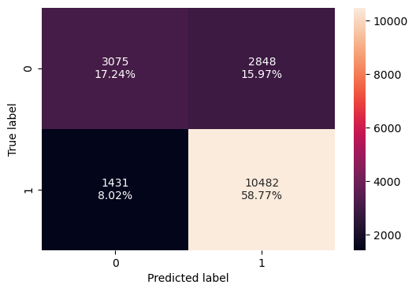

```python
confusion_matrix_sklearn(xgb_tuned,X_train, y_train)
```

```python
xgb_tuned_model_train_perf = model_performance_classification_sklearn(xgb_tuned,X_train, y_train)
xgb_tuned_model_train_perf
```

|  | Accuracy | Recall | Precision | F1 |
| --- | --- | --- | --- | --- |
| 0 | 0.760092 | 0.879879 | 0.786347 | 0.830488 |

#### Comprobación del rendimiento del modelo en el conjunto de prueba

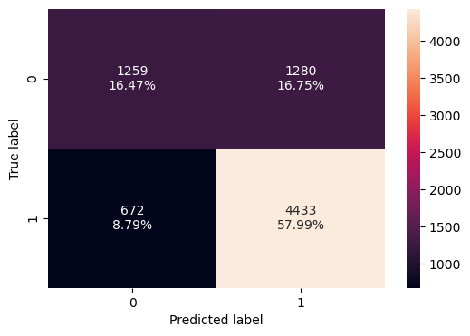

```python
confusion_matrix_sklearn(xgb_tuned,X_test,y_test)
```

```python
xgb_tuned_model_test_perf = model_performance_classification_sklearn(xgb_tuned,X_test,y_test)
xgb_tuned_model_test_perf
```

|  | Accuracy | Recall | Precision | F1 |
| --- | --- | --- | --- | --- |
| 0 | 0.744636 | 0.868364 | 0.77595 | 0.81956 |

- Conjunto de Entrenamiento:

El modelo XGBoost ajustado presenta una exactitud del 76.0% en el conjunto de entrenamiento. La sensibilidad es del 88.0%, la precisión alcanza el 78.6% y el F1 es del 83.0%.

- Conjunto de Prueba:

Para el conjunto de prueba, el modelo tiene una exactitud del 74.5%, con una sensibilidad del 86.8%, una precisión del 77.6% y un F1 del 81.96%.

- Observacion:

El XGBoost ajustado muestra métricas consistentes entre el conjunto de entrenamiento y prueba, indicando una buena generalización. A diferencia de su versión sin ajustar, este modelo ajustado reduce el riesgo de sobreajuste y ofrece un equilibrio más armónico entre precisión y sensibilidad. La pequeña diferencia entre las métricas de entrenamiento y prueba sugiere que el ajuste ha beneficiado al modelo, optimizando su capacidad predictiva en escenarios no vistos.

## Comparación de rendimiento del modelo y conclusiones

```python
# training performance comparison

models_train_comp_df = pd.concat(
    [
        decision_tree_perf_train.T,
        dtree_estimator_model_train_perf.T,
        bagging_classifier_model_train_perf.T,
        bagging_estimator_tuned_model_train_perf.T,
        rf_estimator_model_train_perf.T,
        rf_tuned_model_train_perf.T,
        ab_classifier_model_train_perf.T,
        abc_tuned_model_train_perf.T,
        gb_classifier_model_train_perf.T,
        gbc_tuned_model_train_perf.T,
        xgb_classifier_model_train_perf.T,
        xgb_tuned_model_train_perf.T,

    ],
    axis=1,
)
models_train_comp_df.columns = [
    "Decision Tree",
    "Tuned Decision Tree",
    "Bagging Classifier",
    "Tuned Bagging Classifier",
    "Random Forest",
    "Tuned Random Forest",
    "Adaboost Classifier",
    "Tuned Adaboost Classifier",
    "Gradient Boost Classifier",
    "Tuned Gradient Boost Classifier",
    "XGBoost Classifier",
    "XGBoost Classifier Tuned",

]
print("Training performance comparison:")
models_train_comp_df
```

```
Training performance comparison:
```

|  | Decision Tree | Tuned Decision Tree | Bagging Classifier | Tuned Bagging Classifier | Random Forest | Tuned Random Forest | Adaboost Classifier | Tuned Adaboost Classifier | Gradient Boost Classifier | Tuned Gradient Boost Classifier | XGBoost Classifier | XGBoost Classifier Tuned |
| --- | --- | --- | --- | --- | --- | --- | --- | --- | --- | --- | --- | --- |
| Accuracy | 1.0 | 0.712548 | 0.985198 | 0.996187 | 1.0 | 0.769119 | 0.738226 | 0.718995 | 0.758802 | 0.764017 | 0.850807 | 0.760092 |
| Recall | 1.0 | 0.931923 | 0.985982 | 0.999916 | 1.0 | 0.918660 | 0.887182 | 0.781247 | 0.883740 | 0.882649 | 0.935952 | 0.879879 |
| Precision | 1.0 | 0.720067 | 0.991810 | 0.994407 | 1.0 | 0.776556 | 0.760688 | 0.794587 | 0.783042 | 0.789059 | 0.854537 | 0.786347 |
| F1 | 1.0 | 0.812411 | 0.988887 | 0.997154 | 1.0 | 0.841652 | 0.819080 | 0.787861 | 0.830349 | 0.833234 | 0.893394 | 0.830488 |

```python
# testing performance comparison
models_test_comp_df = pd.concat(
    [
        decision_tree_perf_test.T,
        dtree_estimator_model_test_perf.T,
        bagging_classifier_model_test_perf.T,
        bagging_estimator_tuned_model_test_perf.T,
        rf_estimator_model_test_perf.T,
        rf_tuned_model_test_perf.T,
        ab_classifier_model_test_perf.T,
        abc_tuned_model_test_perf.T,
        gb_classifier_model_test_perf.T,
        gbc_tuned_model_test_perf.T,
        xgb_classifier_model_test_perf.T,
        xgb_tuned_model_test_perf.T,

    ],
    axis=1,
)
models_test_comp_df.columns = [
    "Decision Tree",
    "Tuned Decision Tree",
    "Bagging Classifier",
    "Tuned Bagging Classifier",
    "Random Forest",
    "Tuned Random Forest",
    "Adaboost Classifier",
    "Tuned Adaboost Classifier",
    "Gradient Boost Classifier",
    "Tuned Gradient Boost Classifier",
    "XGBoost Classifier",
    "XGBoost Classifier Tuned",

]
print("Test performance comparison:")
models_test_comp_df
 ## Complete the code to check performance for test data
```

```
Test performance comparison:
```

|  | Decision Tree | Tuned Decision Tree | Bagging Classifier | Tuned Bagging Classifier | Random Forest | Tuned Random Forest | Adaboost Classifier | Tuned Adaboost Classifier | Gradient Boost Classifier | Tuned Gradient Boost Classifier | XGBoost Classifier | XGBoost Classifier Tuned |
| --- | --- | --- | --- | --- | --- | --- | --- | --- | --- | --- | --- | --- |
| Accuracy | 0.664835 | 0.706567 | 0.691523 | 0.724228 | 0.727368 | 0.738095 | 0.734301 | 0.716510 | 0.744767 | 0.743459 | 0.729984 | 0.744636 |
| Recall | 0.742801 | 0.930852 | 0.764153 | 0.895397 | 0.847209 | 0.898923 | 0.885015 | 0.781391 | 0.876004 | 0.871303 | 0.851518 | 0.868364 |
| Precision | 0.752232 | 0.715447 | 0.771711 | 0.743857 | 0.768343 | 0.755391 | 0.757799 | 0.791468 | 0.772366 | 0.773296 | 0.768972 | 0.775950 |
| F1 | 0.747487 | 0.809058 | 0.767913 | 0.812622 | 0.805851 | 0.820930 | 0.816481 | 0.786397 | 0.820927 | 0.819379 | 0.808143 | 0.819560 |

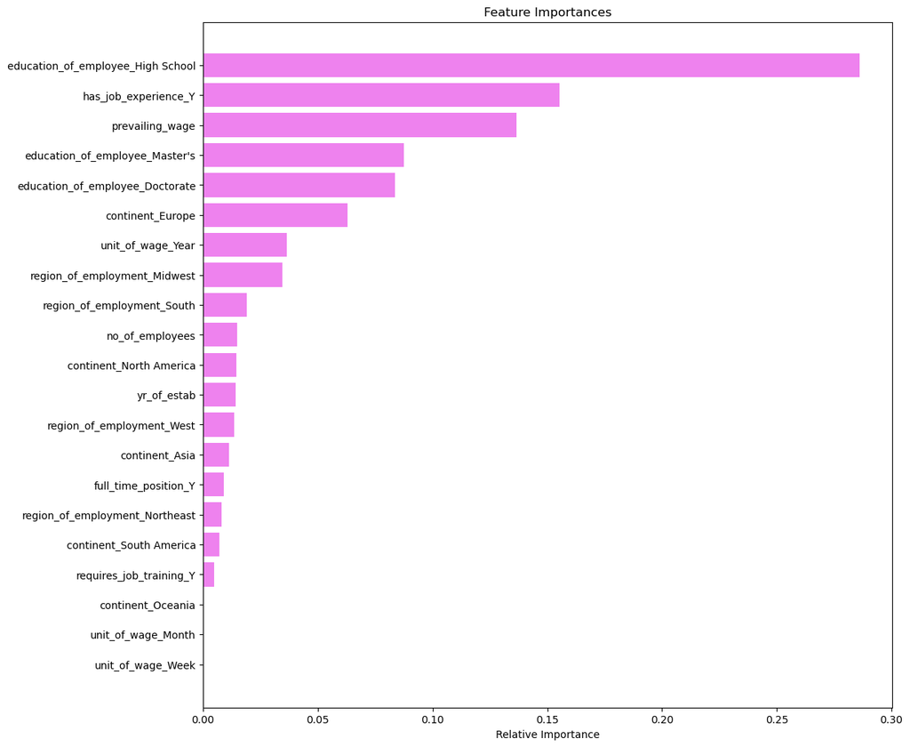

```python
feature_names = X_train.columns
importances = gb_classifier.feature_importances_
indices = np.argsort(importances)

plt.figure(figsize=(12, 12))
plt.title("Feature Importances")
plt.barh(range(len(indices)), importances[indices], color="violet", align="center")
plt.yticks(range(len(indices)), [feature_names[i] for i in indices])
plt.xlabel("Relative Importance")
plt.show()
```

Basándome en los datos proporcionados para los sets de entrenamiento y prueba, podemos sacar las siguientes conclusiones:

- Árbol de Decisiones:

Sobreajuste en el modelo no ajustado, evidenciado por una precisión perfecta en el entrenamiento pero un rendimiento menor en la prueba. El modelo ajustado muestra una mejora en generalización, a pesar de que su precisión en el entrenamiento disminuye.

- Bagging:

Alto rendimiento en el entrenamiento, pero una caída en las métricas de prueba sugiere cierto sobreajuste. El modelo ajustado sigue el mismo patrón, aunque con un leve incremento en la generalización.

- Random Forest:

Sobreajuste evidente en el modelo no ajustado. El ajuste reduce este sobreajuste, acercando las métricas de entrenamiento a las de prueba, y mejorando la generalización.

- Adaboost:

Buen rendimiento en ambos sets sin ajustar, con una ligera disminución en las métricas del modelo ajustado, pero sigue mostrando una buena generalización.

- Gradient Boosting:

El rendimiento es muy similar entre el modelo no ajustado y el ajustado, ambos con buenas métricas de generalización.

- XGBoost:

El modelo no ajustado muestra un alto rendimiento en el entrenamiento pero con una disminución en el conjunto de prueba. La versión ajustada equilibra mejor entre entrenamiento y prueba, mostrando una buena generalización.

- Conclusión: La mayoría de los modelos ajustados presentan una mejor capacidad de generalización en comparación con sus versiones no ajustadas. Los modelos Gradient Boosting, XGBoost ajustado y Random Forest ajustado destacan particularmente por su rendimiento equilibrado en ambos conjuntos. Sin embargo, es importante recordar que la elección del modelo ideal también debe considerar aspectos prácticos, como el tiempo de ejecución y la interpretabilidad. En general, si tuviera que elegir basándome solo en estas métricas, consideraría el XGBoost ajustado o el Gradient Boosting dado su equilibrio y alto rendimiento.

## Información práctica y recomendaciones

> Recomendaciones para la Empresa:
- Sobre los Modelos: La optimización de hiperparámetros ha demostrado ser fundamental para mejorar la generalización de los modelos. Se recomienda priorizar el uso de modelos ajustados, en particular el XGBoost ajustado y el Gradient Boosting, dada su capacidad para equilibrar eficientemente el rendimiento entre conjuntos de entrenamiento y prueba.
- Prevención del Sobreajuste: Es esencial ser cauteloso con modelos que muestran rendimiento perfecto o cercano a la perfección en el conjunto de entrenamiento. Estos modelos pueden no generalizar bien en datos no vistos, lo cual fue evidente en el modelo de Árbol de Decisiones sin ajustar y el Random Forest sin ajustar.
- Evaluación de Costos y Beneficios: Además del rendimiento del modelo, la empresa debe considerar el tiempo de entrenamiento y predicción, y la facilidad de implementación. Por ejemplo, si dos modelos tienen rendimientos similares pero uno es significativamente más rápido o fácil de implementar, podría ser más conveniente optar por ese modelo.

En resumen, para obtener el máximo valor de los modelos de clasificación y asegurar decisiones informadas y precisas sobre las solicitudes de visa, es crucial equilibrar precisión, generalización, eficiencia y interpretabilidad. Se recomienda una revisión periódica y ajuste de los modelos para adaptarse a las cambiantes condiciones y necesidades de la empresa.

> ¿Cuál sería su consejo para hacer crecer el negocio?

Mi consejo sería centrarnos en los modelos ajustados de machine learning, ya que muestran un buen equilibrio entre rendimiento en entrenamiento y pruebas. Además, deberíamos invertir en educación para los solicitantes y mejorar la automatización del proceso de solicitud. Al combinar un sistema eficiente con una experiencia de usuario optimizada, podemos incrementar nuestra base de clientes y fortalecer nuestra posición en el mercado.